# Peer assessment #1 for the course $Reproducible research$

Wednesday, March 11, 2015

This assignment makes use of data from a personal activity monitoring device. This device collects data at 5 minute intervals through out the day. The data consists of two months of data from an anonymous individual collected during the months of October and November, 2012 and include the number of steps taken in 5 minute intervals each day.

The variables included in this dataset are:

- steps: Number of steps taking in a 5-minute interval (missing values are coded as NA)
- date: The date on which the measurement was taken in YYYY-MM-DD format
- interval: Identifier for the 5-minute interval in which measurement was taken

The dataset is stored in a comma-separated-value (CSV) file and there are a total of 17,568 observations in this dataset.

For the purpose of the assessment assume that the data file ‘activity.csv’ is stored in working directory.

Reading the data file….

```r
raw_data<-read.csv("./activity.csv")
```

Answering the questions….

1. What is mean total number of steps taken per day?
- Calculating the total number of steps taken per day

```r
number_of_steps<-with(raw_data,tapply(steps,date,sum,na.rm=TRUE))
print(number_of_steps)
```

```
## 2012-10-01 2012-10-02 2012-10-03 2012-10-04 2012-10-05 2012-10-06
##          0        126      11352      12116      13294      15420
## 2012-10-07 2012-10-08 2012-10-09 2012-10-10 2012-10-11 2012-10-12
##      11015          0      12811       9900      10304      17382
## 2012-10-13 2012-10-14 2012-10-15 2012-10-16 2012-10-17 2012-10-18
##      12426      15098      10139      15084      13452      10056
## 2012-10-19 2012-10-20 2012-10-21 2012-10-22 2012-10-23 2012-10-24
##      11829      10395       8821      13460       8918       8355
## 2012-10-25 2012-10-26 2012-10-27 2012-10-28 2012-10-29 2012-10-30
##       2492       6778      10119      11458       5018       9819
## 2012-10-31 2012-11-01 2012-11-02 2012-11-03 2012-11-04 2012-11-05
##      15414          0      10600      10571          0      10439
## 2012-11-06 2012-11-07 2012-11-08 2012-11-09 2012-11-10 2012-11-11
##       8334      12883       3219          0          0      12608
## 2012-11-12 2012-11-13 2012-11-14 2012-11-15 2012-11-16 2012-11-17
##      10765       7336          0         41       5441      14339
## 2012-11-18 2012-11-19 2012-11-20 2012-11-21 2012-11-22 2012-11-23
##      15110       8841       4472      12787      20427      21194
## 2012-11-24 2012-11-25 2012-11-26 2012-11-27 2012-11-28 2012-11-29
##      14478      11834      11162      13646      10183       7047
## 2012-11-30
##          0
```

- Making a histogram of the total number of steps taken each day

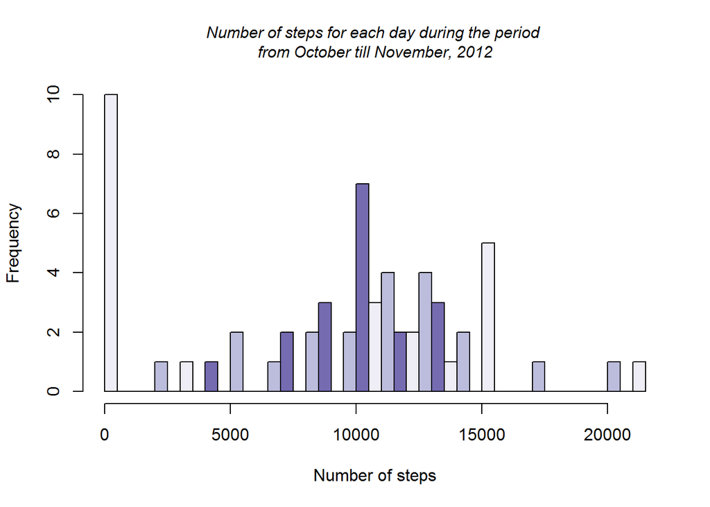

```r
library(datasets)
library(RColorBrewer)
hist(number_of_steps,main="Number of steps for each day during the period \nfrom October till November, 2012",col=brewer.pal(3, "Purples"),
     xlab="Number of steps",breaks=60,font.main=3,cex.main=0.95)
```

- Calculating mean and median of the total number of steps taken per day

```r
mean_number_of_steps<-mean(number_of_steps)
print(mean_number_of_steps)
```

```
## [1] 9354.23
```

```r
median_number_of_steps<-quantile(number_of_steps,probs=c(0.5))
print(median_number_of_steps)
```

```
##   50%
## 10395
```

2. What is the average daily activity pattern?
- Making a time series plot of the 5-minute interval (x-axis) and the average number of steps taken, averaged across all days (y-axis)

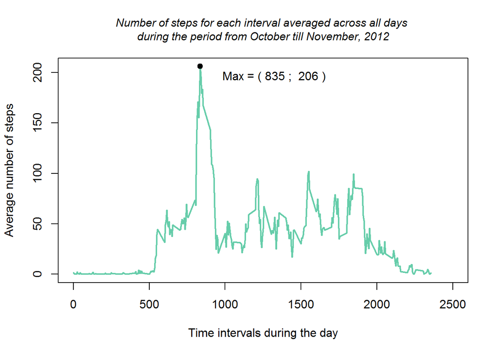

```r
number_of_steps_per_interval<-with(raw_data,tapply(steps,as.factor(interval),mean,na.rm=TRUE))
with(raw_data,{
    plot(unique(interval),number_of_steps_per_interval,type="l",main="Number of steps for each interval averaged across all days \nduring the period from October till November, 2012",xlab="Time intervals during the day",ylab="Average number of steps",font.main=3,lwd=2,col="aquamarine3",xlim=c(0,2500),cex.main=0.95)
    points(as.integer(names(number_of_steps_per_interval[which.max(number_of_steps_per_interval)])),number_of_steps_per_interval[which.max(number_of_steps_per_interval)],pch=19)
    text(as.integer(names(number_of_steps_per_interval[which.max(number_of_steps_per_interval)]))+100,number_of_steps_per_interval[which.max(number_of_steps_per_interval)]-10,,labels=paste("Max = (",expression=names(number_of_steps_per_interval[which.max(number_of_steps_per_interval)]),"; ",expression=round(number_of_steps_per_interval[which.max(number_of_steps_per_interval)],0),")"),pos=4)})
```

- The maximum number of steps (206) contains in the 5-minute interval # 835
3. Imputing missing values
- Calculating the total number of missing values in the dataset (i.e. the total number of rows with NAs)

```r
bad<-!complete.cases(raw_data) ## the operator summary(raw_data) can be also usefull to get information about missing data
print(sum(bad))
```

```
## [1] 2304
```

```
In this case function summary() can be also very useful.
```

- Replacing missing values with the median value for that 5-minute interval and getting new data set

```r
new_data<-raw_data
median_number_of_steps_per_interval<-with(raw_data,tapply(steps,as.factor(interval),quantile,probs=c(0.5),na.rm=TRUE))
for (i in 1:nrow(new_data)) {
    if (match(new_data[[i,3]],as.integer(names(median_number_of_steps_per_interval)))>0 & is.na(new_data[[i,1]])){
         index<-match(new_data[[i,3]],as.integer(names(median_number_of_steps_per_interval)))
         new_data[[i,1]]<-median_number_of_steps_per_interval[index]
    }
}
```

- Making hystogram of the total number of steps taken each day using new data set (with NA values replaced median value for the 5-minute interval)

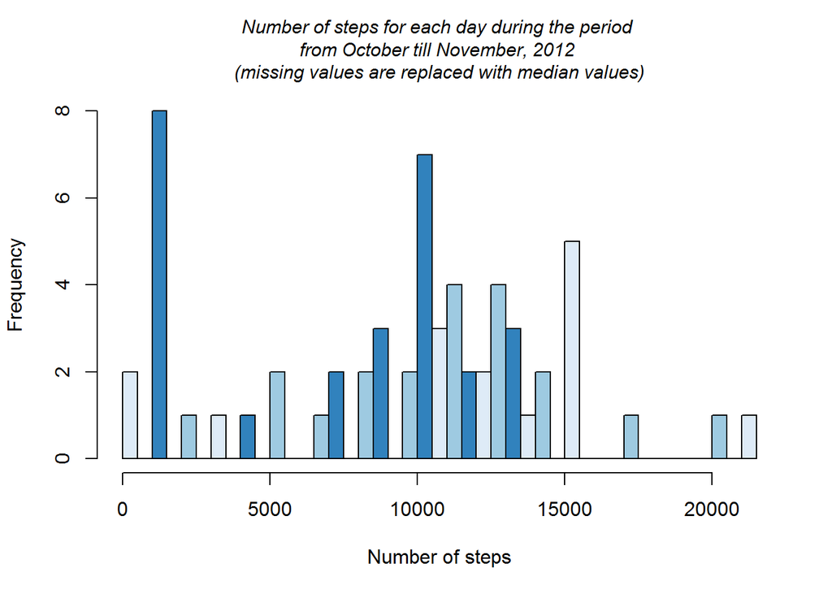

```r
number_of_steps_new_data<-with(new_data,tapply(steps,date,sum))
hist(number_of_steps_new_data,main="Number of steps for each day during the period \nfrom October till November, 2012 \n(missing values are replaced with median values)",col=brewer.pal(3, "Blues"),
     xlab="Number of steps",breaks=60,font.main=3,cex.main=0.95)
```

```r
print("Mean number of steps taken per day (missing values are replaced with median values)")
```

```
## [1] "Mean number of steps taken per day (missing values are replaced with median values)"
```

```r
print(with(new_data,tapply(steps,date,mean)))
```

```
## 2012-10-01 2012-10-02 2012-10-03 2012-10-04 2012-10-05 2012-10-06
##  3.9618056  0.4375000 39.4166667 42.0694444 46.1597222 53.5416667
## 2012-10-07 2012-10-08 2012-10-09 2012-10-10 2012-10-11 2012-10-12
## 38.2465278  3.9618056 44.4826389 34.3750000 35.7777778 60.3541667
## 2012-10-13 2012-10-14 2012-10-15 2012-10-16 2012-10-17 2012-10-18
## 43.1458333 52.4236111 35.2048611 52.3750000 46.7083333 34.9166667
## 2012-10-19 2012-10-20 2012-10-21 2012-10-22 2012-10-23 2012-10-24
## 41.0729167 36.0937500 30.6284722 46.7361111 30.9652778 29.0104167
## 2012-10-25 2012-10-26 2012-10-27 2012-10-28 2012-10-29 2012-10-30
##  8.6527778 23.5347222 35.1354167 39.7847222 17.4236111 34.0937500
## 2012-10-31 2012-11-01 2012-11-02 2012-11-03 2012-11-04 2012-11-05
## 53.5208333  3.9618056 36.8055556 36.7048611  3.9618056 36.2465278
## 2012-11-06 2012-11-07 2012-11-08 2012-11-09 2012-11-10 2012-11-11
## 28.9375000 44.7326389 11.1770833  3.9618056  3.9618056 43.7777778
## 2012-11-12 2012-11-13 2012-11-14 2012-11-15 2012-11-16 2012-11-17
## 37.3784722 25.4722222  3.9618056  0.1423611 18.8923611 49.7881944
## 2012-11-18 2012-11-19 2012-11-20 2012-11-21 2012-11-22 2012-11-23
## 52.4652778 30.6979167 15.5277778 44.3993056 70.9270833 73.5902778
## 2012-11-24 2012-11-25 2012-11-26 2012-11-27 2012-11-28 2012-11-29
## 50.2708333 41.0902778 38.7569444 47.3819444 35.3576389 24.4687500
## 2012-11-30
##  3.9618056
```

```r
print("Median number of steps taken per day (missing values are replaced with median values)")
```

```
## [1] "Median number of steps taken per day (missing values are replaced with median values)"
```

```r
print(with(new_data,tapply(steps,date,quantile,probs=c(0.5))))
```

```
## 2012-10-01 2012-10-02 2012-10-03 2012-10-04 2012-10-05 2012-10-06
##          0          0          0          0          0          0
## 2012-10-07 2012-10-08 2012-10-09 2012-10-10 2012-10-11 2012-10-12
##          0          0          0          0          0          0
## 2012-10-13 2012-10-14 2012-10-15 2012-10-16 2012-10-17 2012-10-18
##          0          0          0          0          0          0
## 2012-10-19 2012-10-20 2012-10-21 2012-10-22 2012-10-23 2012-10-24
##          0          0          0          0          0          0
## 2012-10-25 2012-10-26 2012-10-27 2012-10-28 2012-10-29 2012-10-30
##          0          0          0          0          0          0
## 2012-10-31 2012-11-01 2012-11-02 2012-11-03 2012-11-04 2012-11-05
##          0          0          0          0          0          0
## 2012-11-06 2012-11-07 2012-11-08 2012-11-09 2012-11-10 2012-11-11
##          0          0          0          0          0          0
## 2012-11-12 2012-11-13 2012-11-14 2012-11-15 2012-11-16 2012-11-17
##          0          0          0          0          0          0
## 2012-11-18 2012-11-19 2012-11-20 2012-11-21 2012-11-22 2012-11-23
##          0          0          0          0          0          0
## 2012-11-24 2012-11-25 2012-11-26 2012-11-27 2012-11-28 2012-11-29
##          0          0          0          0          0          0
## 2012-11-30
##          0
```

```r
print("Mean number of steps taken per day (with missing values)")
```

```
## [1] "Mean number of steps taken per day (with missing values)"
```

```r
print(with(raw_data,tapply(steps,date,mean,na.rm=TRUE)))
```

```
## 2012-10-01 2012-10-02 2012-10-03 2012-10-04 2012-10-05 2012-10-06
##        NaN  0.4375000 39.4166667 42.0694444 46.1597222 53.5416667
## 2012-10-07 2012-10-08 2012-10-09 2012-10-10 2012-10-11 2012-10-12
## 38.2465278        NaN 44.4826389 34.3750000 35.7777778 60.3541667
## 2012-10-13 2012-10-14 2012-10-15 2012-10-16 2012-10-17 2012-10-18
## 43.1458333 52.4236111 35.2048611 52.3750000 46.7083333 34.9166667
## 2012-10-19 2012-10-20 2012-10-21 2012-10-22 2012-10-23 2012-10-24
## 41.0729167 36.0937500 30.6284722 46.7361111 30.9652778 29.0104167
## 2012-10-25 2012-10-26 2012-10-27 2012-10-28 2012-10-29 2012-10-30
##  8.6527778 23.5347222 35.1354167 39.7847222 17.4236111 34.0937500
## 2012-10-31 2012-11-01 2012-11-02 2012-11-03 2012-11-04 2012-11-05
## 53.5208333        NaN 36.8055556 36.7048611        NaN 36.2465278
## 2012-11-06 2012-11-07 2012-11-08 2012-11-09 2012-11-10 2012-11-11
## 28.9375000 44.7326389 11.1770833        NaN        NaN 43.7777778
## 2012-11-12 2012-11-13 2012-11-14 2012-11-15 2012-11-16 2012-11-17
## 37.3784722 25.4722222        NaN  0.1423611 18.8923611 49.7881944
## 2012-11-18 2012-11-19 2012-11-20 2012-11-21 2012-11-22 2012-11-23
## 52.4652778 30.6979167 15.5277778 44.3993056 70.9270833 73.5902778
## 2012-11-24 2012-11-25 2012-11-26 2012-11-27 2012-11-28 2012-11-29
## 50.2708333 41.0902778 38.7569444 47.3819444 35.3576389 24.4687500
## 2012-11-30
##        NaN
```

```r
print("Median number of steps taken per day (with missing values)")
```

```
## [1] "Median number of steps taken per day (with missing values)"
```

```r
print(with(raw_data,tapply(steps,date,quantile,probs=c(0.5),na.rm=TRUE)))
```

```
## 2012-10-01 2012-10-02 2012-10-03 2012-10-04 2012-10-05 2012-10-06
##         NA          0          0          0          0          0
## 2012-10-07 2012-10-08 2012-10-09 2012-10-10 2012-10-11 2012-10-12
##          0         NA          0          0          0          0
## 2012-10-13 2012-10-14 2012-10-15 2012-10-16 2012-10-17 2012-10-18
##          0          0          0          0          0          0
## 2012-10-19 2012-10-20 2012-10-21 2012-10-22 2012-10-23 2012-10-24
##          0          0          0          0          0          0
## 2012-10-25 2012-10-26 2012-10-27 2012-10-28 2012-10-29 2012-10-30
##          0          0          0          0          0          0
## 2012-10-31 2012-11-01 2012-11-02 2012-11-03 2012-11-04 2012-11-05
##          0         NA          0          0         NA          0
## 2012-11-06 2012-11-07 2012-11-08 2012-11-09 2012-11-10 2012-11-11
##          0          0          0         NA         NA          0
## 2012-11-12 2012-11-13 2012-11-14 2012-11-15 2012-11-16 2012-11-17
##          0          0         NA          0          0          0
## 2012-11-18 2012-11-19 2012-11-20 2012-11-21 2012-11-22 2012-11-23
##          0          0          0          0          0          0
## 2012-11-24 2012-11-25 2012-11-26 2012-11-27 2012-11-28 2012-11-29
##          0          0          0          0          0          0
## 2012-11-30
##         NA
```

```r
library(lubridate)
new_data$weekday<-vector(mode="character",length=nrow(new_data))
for (i in 1:nrow(new_data)) {
 if (wday(as.POSIXct(new_data[[i,2]])) <=5) {
     new_data[[i,4]]<-"weekdays"
 }
 else {new_data[[i,4]]<-"weekends"}
}
new_data$weekday<-as.factor(new_data$weekday)
```

```r
library(plyr)
```

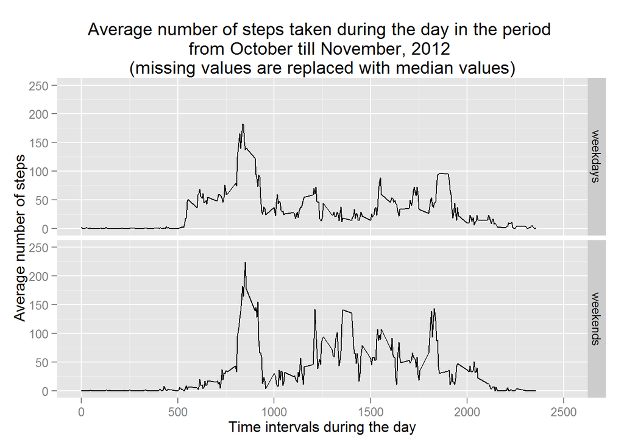

```r
new_data_avg <- ddply(new_data, c("interval", "weekday"), summarise, mean = mean(steps))

library(ggplot2)
qplot(interval,mean,data=new_data_avg,facets=weekday~.,xlab="Time intervals during the day",ylab="Average number of steps",xlim=c(0,2500),ylim=c(0,250),geom=c("line"),main="Average number of steps taken during the day in the period \nfrom October till November, 2012 \n(missing values are replaced with median values)")
```